# Straight - MIS545 - Lab 5

Lab 5: Association Rules

Ryan Straight  
2020-08-16

# Problem Description

The `Congressional Voting Records` dataset includes votes for each of the U.S. House of Representatives Congressmen on the 16 votes, such as Handicapped Infants and Toddler Act (`handicapped-infants`), Cost Sharing for Federal Water Projects (`water-project-cost-sharing`), Adoption of the Budget Resolution (`adoption-of-the-budget-resolution`), etc. There are three possible vote results: yea, represented as ‘`y`’, nay, represented as ‘`n`’ and unknown disposition, represented as ‘`?`’. Unknown votes are treated as missing data.

## Assignment steps

1. Show your R source code in the Word file.
2. List the top 5 frequent association rules sorted by Support, regardless of party. Also show the rules in a two-key plot.
3. List two most frequent association rules sorted by Confidence for each party.
4. Generate the parallel coordinates plot for Question 2 result.
5. Generate association rules network for Question 2 result. Please use both igraph and visNetwork packages.
6. Briefly discuss how to evaluate association rules. (One paragraph should be sufficient)
7. In what scenario, an association rule with high confidence could be a misleading rule?

# Step 1

> Show your R source code in the Word file.

```r
# Get the data in
voting <- read_csv("voting.csv", na = "?") %>%
  mutate_all(as.factor)

# Take a look at the construction and spread of the data
glimpse(voting)
```

```
Rows: 435
Columns: 17
$ party                                    <fct> republican, repu...
$ `handicapped-infants`                    <fct> n, n, NA, n, y, ...
$ `water-project-cost-sharing`             <fct> y, y, y, y, y, y...
$ `adoption-of-the-budget-resolution`      <fct> n, n, y, y, y, y...
$ `physician-fee-freeze`                   <fct> y, y, NA, n, n, ...
$ `el-salvador-aid`                        <fct> y, y, y, NA, y, ...
$ `religious-groups-in-schools`            <fct> y, y, y, y, y, y...
$ `anti-satellite-test-ban`                <fct> n, n, n, n, n, n...
$ `aid-to-nicaraguan-contras`              <fct> n, n, n, n, n, n...
$ `mx-missile`                             <fct> n, n, n, n, n, n...
$ immigration                              <fct> y, n, n, n, n, n...
$ `synfuels-corporation-cutback`           <fct> NA, n, y, y, y, ...
$ `education-spending`                     <fct> y, y, n, n, NA, ...
$ `superfund-right-to-sue`                 <fct> y, y, y, y, y, y...
$ crime                                    <fct> y, y, y, n, y, y...
$ `duty-free-exports`                      <fct> n, n, n, n, y, y...
$ `export-administration-act-south-africa` <fct> y, NA, n, y, y, ...
```

```r
skim(voting)
```

Table 1: Data summary

| Name | voting |
| --- | --- |
| Number of rows | 435 |
| Number of columns | 17 |
| _______________________ |  |
| Column type frequency: |  |
| factor | 17 |
| ________________________ |  |
| Group variables | None |

**Variable type: factor**

| skim_variable | n_missing | complete_rate | ordered | n_unique | top_counts |
| --- | --- | --- | --- | --- | --- |
| party | 0 | 1.00 | FALSE | 2 | dem: 267, rep: 168 |
| handicapped-infants | 12 | 0.97 | FALSE | 2 | n: 236, y: 187 |
| water-project-cost-sharing | 48 | 0.89 | FALSE | 2 | y: 195, n: 192 |
| adoption-of-the-budget-resolution | 11 | 0.97 | FALSE | 2 | y: 253, n: 171 |
| physician-fee-freeze | 11 | 0.97 | FALSE | 2 | n: 247, y: 177 |
| el-salvador-aid | 15 | 0.97 | FALSE | 2 | y: 212, n: 208 |
| religious-groups-in-schools | 11 | 0.97 | FALSE | 2 | y: 272, n: 152 |
| anti-satellite-test-ban | 14 | 0.97 | FALSE | 2 | y: 239, n: 182 |
| aid-to-nicaraguan-contras | 15 | 0.97 | FALSE | 2 | y: 242, n: 178 |
| mx-missile | 22 | 0.95 | FALSE | 2 | y: 207, n: 206 |
| immigration | 7 | 0.98 | FALSE | 2 | y: 216, n: 212 |
| synfuels-corporation-cutback | 21 | 0.95 | FALSE | 2 | n: 264, y: 150 |
| education-spending | 31 | 0.93 | FALSE | 2 | n: 233, y: 171 |
| superfund-right-to-sue | 25 | 0.94 | FALSE | 2 | y: 209, n: 201 |
| crime | 17 | 0.96 | FALSE | 2 | y: 248, n: 170 |
| duty-free-exports | 28 | 0.94 | FALSE | 2 | n: 233, y: 174 |
| export-administration-act-south-africa | 104 | 0.76 | FALSE | 2 | y: 269, n: 62 |

```r
# Track rules of both democrat and republican
rules <- apriori(voting, parameter = list(sup = 0.35, conf = 0.8, target = "rules"), appearance = list(default = 'lhs', rhs = c('party=democrat','party=republican')))
```

```
Apriori

Parameter specification:
 confidence minval smax arem  aval originalSupport maxtime support
        0.8    0.1    1 none FALSE            TRUE       5    0.35
 minlen maxlen target  ext
      1     10  rules TRUE

Algorithmic control:
 filter tree heap memopt load sort verbose
    0.1 TRUE TRUE  FALSE TRUE    2    TRUE

Absolute minimum support count: 152

set item appearances ...[2 item(s)] done [0.00s].
set transactions ...[34 item(s), 435 transaction(s)] done [0.00s].
sorting and recoding items ... [31 item(s)] done [0.00s].
creating transaction tree ... done [0.00s].
checking subsets of size 1 2 3 4 5 6 done [0.00s].
writing ... [111 rule(s)] done [0.00s].
creating S4 object  ... done [0.00s].
```

# Step 2

> List the top 5 frequent association rules sorted by Support, regardless of party. Also show the rules in a two-key plot.

```r
# Create rules
rules <- sort(rules, decreasing = TRUE, by = "support")
top5_support <- rules[1:5] %>% sort(decreasing = TRUE, by = "support")
inspect(top5_support)
```

```
    lhs                                      rhs                support confidence  coverage     lift count
[1] {physician-fee-freeze=n}              => {party=democrat} 0.5632184  0.9919028 0.5678161 1.616021   245
[2] {adoption-of-the-budget-resolution=y} => {party=democrat} 0.5310345  0.9130435 0.5816092 1.487543   231
[3] {adoption-of-the-budget-resolution=y,
     physician-fee-freeze=n}              => {party=democrat} 0.5034483  1.0000000 0.5034483 1.629213   219
[4] {aid-to-nicaraguan-contras=y}         => {party=democrat} 0.5011494  0.9008264 0.5563218 1.467639   218
[5] {education-spending=n}                => {party=democrat} 0.4896552  0.9141631 0.5356322 1.489367   213
```

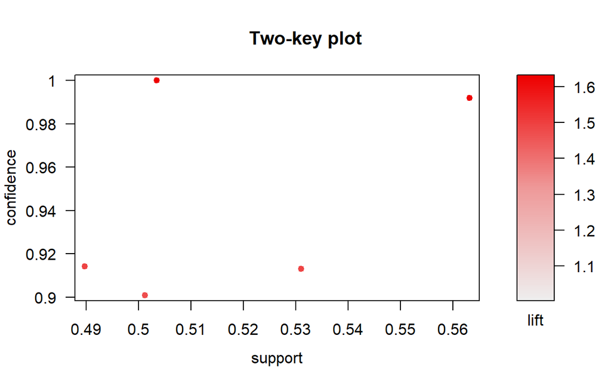

```r
# Overview plot, quesiton #2 continued
plot(top5_support, shading="lift", control=list(main = "Two-key plot"))
```

# Step 3

> List two most frequent association rules sorted by Confidence for each party.

```r
# Separate parties
rules_d <- apriori(voting, parameter = list(sup = 0.35, conf = 0.8, target = "rules"), appearance = list(default = 'lhs', rhs = 'party=democrat'))
```

```
Apriori

Parameter specification:
 confidence minval smax arem  aval originalSupport maxtime support
        0.8    0.1    1 none FALSE            TRUE       5    0.35
 minlen maxlen target  ext
      1     10  rules TRUE

Algorithmic control:
 filter tree heap memopt load sort verbose
    0.1 TRUE TRUE  FALSE TRUE    2    TRUE

Absolute minimum support count: 152

set item appearances ...[1 item(s)] done [0.00s].
set transactions ...[34 item(s), 435 transaction(s)] done [0.00s].
sorting and recoding items ... [31 item(s)] done [0.00s].
creating transaction tree ... done [0.00s].
checking subsets of size 1 2 3 4 5 6 done [0.00s].
writing ... [108 rule(s)] done [0.00s].
creating S4 object  ... done [0.00s].
```

```r
rules_r <- apriori(voting, parameter = list(sup = 0.35, conf = 0.8, target = "rules"), appearance = list(default = 'lhs', rhs = 'party=republican'))
```

```
Apriori

Parameter specification:
 confidence minval smax arem  aval originalSupport maxtime support
        0.8    0.1    1 none FALSE            TRUE       5    0.35
 minlen maxlen target  ext
      1     10  rules TRUE

Algorithmic control:
 filter tree heap memopt load sort verbose
    0.1 TRUE TRUE  FALSE TRUE    2    TRUE

Absolute minimum support count: 152

set item appearances ...[1 item(s)] done [0.00s].
set transactions ...[34 item(s), 435 transaction(s)] done [0.00s].
sorting and recoding items ... [31 item(s)] done [0.00s].
creating transaction tree ... done [0.00s].
checking subsets of size 1 2 3 4 5 6 done [0.00s].
writing ... [3 rule(s)] done [0.00s].
creating S4 object  ... done [0.00s].
```

```r
# Sort the two parties' groups of rules
rules_r <- sort(rules_r, decreasing = TRUE, by = "confidence")
rules_d <- sort(rules_d, decreasing = TRUE, by = "confidence")

# Show top 2 for each by confidence, homework question 3
inspect(rules_r[1:2])
```

```
    lhs                         rhs                  support confidence  coverage     lift count
[1] {physician-fee-freeze=y,
     el-salvador-aid=y}      => {party=republican} 0.3586207  0.9285714 0.3862069 2.404337   156
[2] {physician-fee-freeze=y,
     crime=y}                => {party=republican} 0.3563218  0.9226190 0.3862069 2.388924   155
```

```r
inspect(rules_d[1:2])
```

```
    lhs                                      rhs                support confidence  coverage     lift count
[1] {physician-fee-freeze=n,
     crime=n}                             => {party=democrat} 0.3747126          1 0.3747126 1.629213   163
[2] {adoption-of-the-budget-resolution=y,
     crime=n}                             => {party=democrat} 0.3632184          1 0.3632184 1.629213   158
```